# R Package ‘stratifyR’

K.G. Reddy & M.G.M. Khan

June 04, 2026

**Type** Package

**Title** Optimal Stratification of Univariate Populations

**Version** 2.0-1

**Date** 2026-06-04

**Author** Karuna G. Reddy, M.G.M. Khan

**Maintainer** Karuna G. Reddy <karuna.reddy@auckland.ac.nz>

**Description** This implements the stratification of univariate populations under stratified sampling designs using the method of Khan et al. (2002) https://doi.org/10.1177/0008068320020518, Khan et al. (2008) https://www150.statcan.gc.ca/n1/pub/12-001-x/2008002/article/10761-eng.pdf and Khan et al. (2015) https://doi.org/10.1080/02664763.2015.1018674. It determines the Optimum Strata Boundaries (OSB) and Optimum Sample Sizes (OSS) for the study variable, $y$, using the best-fit frequency distribution of a survey variable (if data is available) or a hypothetical distribution (if data is not available). The method formulates the problem of determining the OSB as mathematical programming problem which is solved by using a dynamic programming technique. If a dataset of the population is available to the surveyor, the method estimates its best-fit distribution and determines the OSB and OSS under Neyman allocation directly. When the dataset is not available, stratification is made based on the assumption that the values of the study variable, $y$, are available as hypothetical realizations of proxy values of $y$ from recent surveys. Thus, it requires certain distributional assumptions about the study variable. At present, it handles stratification for the populations where the study variable follows a continuous distribution, namely, Pareto, Triangular, Right-triangular, Weibull, Gamma, Exponential, Uniform, Normal, Log-normal and Cauchy distributions. In this vignette, the two major functionalities in the package are applied to a number of real and simulated populations and to some hypothetical populations.

**License** GPL (>= 2)

**LazyData** yes

**NeedsCompilation** yes

**Depends** R (>= 4.4.2), MASS, fitdistrplus, actuar, triangle, mc2d, zipfR

**Repository** CRAN

**Date/Publication** 2026-06-04 10:00:00

# Using stratifyR through the interactive app

The quickest and easiest way to use **stratifyR** is through its built-in interactive application. The app gives you the complete workflow — load your own data or pick a built-in dataset, compute the Optimum Strata Boundaries (OSB) and Optimum Sample Sizes (OSS) with the DP, COBYLA or GLOBAL solvers, compare design efficiencies, explore the boundaries visually, and download the results — entirely through a point-and-click interface, with no R programming required. For most users, and especially for anyone who wants results quickly, this is the recommended way to work with the package.

To launch it, install the app’s helper packages once (if you do not already have them) and then call `stratifyRApp()`:

```r
# One-time install of the app's helper packages (skip any you already have)
install.packages(c("shiny", "bslib", "DT"))

# Optional extras: interactive 3-D / slider plots and Excel (.xlsx) import
install.packages(c("plotly", "readxl"))

# Launch the app
library(stratifyR)
stratifyRApp()
```

The application opens in your web browser (or as a standalone desktop-style window). The remainder of this vignette documents the underlying R functions, for readers who prefer to script their analyses or embed **stratifyR** in a larger workflow.

# 1 Introduction

The main aim of stratification is to produce estimators with a small variance when a population characteristic $(y)$ is under study. A simple method that can be used to create strata for this population, if $y$ itself is the stratification variable. The ideal situation is that the distribution of such a study variable is known and the OSB can be determined by placing boundaries on the range of this distribution at suitable cut-points. This problem of determining the OSB, when both the estimation and stratification variables are the same, was first discussed by Dalenius (1950). He provided equations for the determination of stratum boundaries that minimize the variance of population estimates under optimal allocation. Dalenius (1957) futher proposed a solution to the problem by taking equal intervals of the cumulative square root of frequency scale of the stratification variable.

One of the many kinds of stratification methods that has been proposed in the literature is due to Bühler and Deutler (1975). They formulated the problem of determining OSB as an optimization problem and developed a computational technique to solve the problem by using Dynamic Programming (DP). A good review of this method can be found in Khan et al. (2008). The procedure is also applied by Khan et al. (2002), Khan et al. (2003), Khan et al. (2005), Khan et al. (2008), Khan et al. (2009), Khan, Rao, et al. (2015), Khan, Reddy, et al. (2015) for determining OSB for many different distributions. With the known frequency function of the study variable, they considered the problem of finding OSB as an equivalent problem of determining Optimum Strata Width (OSW), which is formulated as a Mathematical Programming Problem (MPP) and solved by using DP technique. They applied the technique to several univariate populations where the study variables followed different probability distributions. In this package, a univariate stratification technique is developed, which is based on the probability distribution assumed by the stratification variable as discussed by the authors above.

As implemented in this package, there are many advantages of using the method. The real advantage of the **stratifyR** package is that when the dataset of the study variable is not available, which may occur in practice, the package is still able to construct OSB and OSS based on the distributional assumption on the data. Moreover, the population survey can be a costly and time-consuming affair, hence, this approach also has the advantage of determining OSB for the study variable that is not available prior to conducting the survey. This, of course, requires certain distributional or parametric assumptions on the study variables, which can easily be obtained from recent or past surveys.

Other advantages of the method are that it leads to substantial gains in the precision of the estimates over other available methods. Results reveal that the variances get smaller with increasing number of strata $(L)$, and they get much smaller at a much faster rate than other available methods. Once the OSB have been determined, the Optimum Sample Sizes (OSS) can be easily calculated for each stratum using Neyman allocation (Neyman (1934)). The algorithm may be a little slow, however, it does provide very efficient results which is probably the most important objective of our survey estimation efforts.

# 2 The Package in a Glance

The **stratifyR** package implements the DP technique (from various literature by Khan et al) as a stratification procedure for univariate populations, when the stratification variable follows a continuous probability distribution, namely: uniform, triangular, right-triangular, pareto, exponential, normal, log-normal, cauchy, weibull and gamma. The package is able to determine the OSB and OSS from real data and as well as hypothetical situations when the dataset is not available. The latter requires some assumptions about the distribution and its initial value, range, parameter values, fixed sample size, etc.

There are two major functions which basically solve the two types of stratification problems: **strata.data()** which carries out univariate stratification for those univariate populations where dataset is available and **strata.distr()** which performs stratification when dataset is not available prior to conducting the survey.

In the former case, data on the study variable, number of strata $(h)$, fixed sample size $(n)$ and population size $(N)$ are used as the input arguments to the **strata.data()** function in the package. In the latter case, **strata.distr()** function is called which requires the distribution to be assumed, its parameters, the inital value and the estimated range of the distribution, fixed sample $(n)$ and population sizes $(N)$. When executed, both the functions output the OSB and OSS, amongst other quantities such as stratum weight $(W_{h})$, stratum variance $(S_{h}^{2})$, stratum objective function values $(W_{h}S_{h})$, stratum sample sizes $(n_{h})$, stratum population sizes $(N_{h})$ and stratum sampling fraction $(f_{h})$.

The following sections show the general formulation of the problem of stratification, the DP solution procedure, the concept of Neyman allocation as the method of determining sample size and the overview of package functionalities. The package is then applied to numerous survey populations with real and simulated data to illustrate its application.

# 3 General Formulation of the Univariate Stratification Problem

Let the target population of the variable under study be stratified into $L$ strata where the estimation of the mean of the study variable $(y)$ is of interest. If a simple random sample of size $n_{h}$ is to be drawn from $h^{th}$ stratum with sample mean $\bar{y}_{h}$, then the stratified sample mean, $\bar{y}_{st}$, is given by
$$\begin{eqnarray}
\bar{y}_{st}=\sum_{h=1}^{L}W_{h}\bar{y}_{h}, \tag{1}
\end{eqnarray}$$
where $W_{h}$ (stratum weight) is the proportion of the population contained in the $h^{th}$ stratum.

When the finite population correction factors are ignored, under the Neyman (1934) allocation, the variance of $\bar{y}_{st}$ is given by
$$\begin{eqnarray}
Var(\bar{y}_{st})=\dfrac{\left(\sum_{h=1}^{L}W_{h}S_{h}\right)^{2}}{n},
\tag{2}
\end{eqnarray}$$
where $S_{h}^{2}$ is the stratum variance for the study variable in the $h^{th}$ (where $h=1, 2, ..., L$) stratum and $n$ is the preassigned total sample size.

Let $f(y);\;a\leq y\leq b$ be the frequency function of the study variable, $y$, on which OSB are to be constructed. If the population mean of this study variable is estimated under Neyman allocation, then the problem of determining OSB is to cut up the range, $d=b-a$, at $(L-1)$ intermediate points $a=y_{0} \leq y_{1} \leq y_{2} \leq, ..., \leq y_{L-1} \leq y_{L}=b\,$ such that (2) is minimum. The lower and upper bounds of the study variable are denoted by $a$ and $b$ respectively and the cut-points $y_{0}, y_{1}, y_{2}, ..., y_{L-1}$ are the OSB.

For a fixed sample size $n$, minimizing the expression of the right hand side of equation (2) is equivalent to minimizing
$$\begin{eqnarray}
\sum_{h=1}^{L} W_{h}S_{h} \tag{3}
\end{eqnarray}$$

If $f(y)$ is known and integrable, the stratum weight $(W_{h})$, stratum variance $(S_{h}^{2})$ and stratum mean $(\mu_{h})$ can be obtained as a function of the boundary points $y_{h}$ and $y_{h-1}$ by using the following expressions:
$$\begin{eqnarray}\label{stratumweight}
W_{h} = \int_{y_{h-1}}^{y_{h}} f(y)dy \tag{4}
\end{eqnarray}$$

$$\begin{eqnarray}
S_{h}^{2}= \dfrac{1}{W_{h}}\int_{y_{h-1}}^{y_{h}}y^{2}f(y)dy -
\mu_{h}^{2} \tag{5}
\end{eqnarray}$$

$$\begin{eqnarray}
\textrm{where}\;\;\;\mu_{h}=\dfrac{1}{W_{h}}\int_{y_{h-1}}^{y_{h}}yf(y)dy
\tag{6}
\end{eqnarray}$$

where $(y_{h-1}, y_{h})$ are the boundaries of $h^{th}$ stratum.

Thus, the objective function in (3) could be expressed as a function of boundary points $y_{h}$ and $y_{h-1}$ only. We further define
$$\begin{eqnarray}
l_{h}=y_{h}-y_{h-1}; \; h=1,2, ..., L \tag{7}
\end{eqnarray}$$

where $l_{h}\geq 0$ denotes the range or width of the $h^{th}$ stratum. Then, the range of the distribution, $d = b - a$, is expressed as a function of stratum width as:
$$\begin{eqnarray}\label{215}
\sum_{h=1}^{L}l_{h}=\sum_{h=1}^{L}(y_{h}-y_{h-1}) = b-a = y_{L} - y_{0}
= d \tag{8}
\end{eqnarray}$$
The $h^{th}$ stratification point $y_{h};\;h=1,2,..., L\,$ is then expressed as $y_{h}=y_{h-1}+l_{h}$ and from (8), the problem can be treated as an equivalent problem of determining Optimum Strata Widths (OSW), $l_{1}, l_{2}, ..., l_{L}$. Due to the special nature of functions, the problem may be treated as a function of $l_{h}$ alone and can be expressed as:
$$\begin{eqnarray}\label{genMPP}
&\textrm{Minimize}& \;\;\;
\sum_{h=1}^{L}\phi_{h}(l_{h}),\nonumber
\\
&\textrm{subject to}&\;\;\;\; \sum_{h=1}^{L}l_{h} =
d,\nonumber
\\
&\textrm{and}& \;\;\;\; l_{h} \geq 0; \;\; h =
1,2,...,L. \tag{9}
\end{eqnarray}$$

# 4 Dynamic Programming Technique as a Solution Procedure

Many multistage decision problems can be formulated as a Mathematical Programming Problem (MPP). The Dynamic Programming technique, developed by Bellman, R E (1957), is a computational method which is well suited for solving MPPs that may be treated as a multistage decision problem. The DP technique determines the optimum solution of a multistage problem by decomposing it into stages, each stage comprising of a single stage. The advantage of the decomposition is that the optimization process at each stage involves one variable only, which simplifies the computational task by dealing with all variables simultaneously.

The solution to an MPP is achieved in a sequential manner starting from one stage problem, moving onto a two stage problem, to a three stage problem and so on until finally all stages are included. The solution for $n$ stages is obtained by adding the $n^{th}$ stage to the solution of $n - 1$ stages.

The basic concept of DP technique is contained in the principle of optimality proclaimed by Bellman, R E (1957), which implies that given the initial state of a system, an optimal policy for the subsequent stages does not depend upon the policy adopted at the preceding stages. It determines the optimum solution of a multi-variable problem by decomposing it into stages, each stage compromising a single variable sub-problem. A dynamic programming model is basically a recursive equation which links the different stages of the problem in a manner which guarantees that each stage’s optimal feasible solution is also optimum and feasible for the entire problem.

Consider the following sub-problem of (9) for first $k(<L)$ strata:

$$\begin{eqnarray}
&\text{Minimize}& \;\;\;\;
\sum_{h=1}^{k}\phi_{h}(l_{h}),\nonumber
\\
&\text{subject to}&\;\;\;\;\; \sum_{h=1}^{k}l_{h} =
d_{k},\nonumber
\\
&\text{and}& \;\;\;\;\; l_{h} \geq 0; \;\; h =
1,2,...,k.\tag{10}
\end{eqnarray}$$

where $d_{k}< d$ is the total width available for division into strata or the state value at stage $k$. Note that $d_{k} = d$ for $k = L$.

The transformation functions are given by:

$$\begin{eqnarray*}
d_{k}\;\;&=&\;\;l_{1}+l_{2}+...+l_{k},\\
d_{k-1}\;\;&=&\;\;l_{1}+l_{2}+...+l_{k-1}\;=\;d_{k}-l_{k},\\
d_{k-2}\;\;&=&\;\;l_{1}+l_{2}+...+l_{k-2}\;=\;d_{k-1}-l_{k-1},\\
&\vdots&\;\;\;\;\;\;\;\;\;\;\;\;\vdots\\
d_{2}\;\;&=&\;\;l_{1}+l_{2}\;=\;d_{3}-l_{3},\\
d_{1}\;\;&=&\;\;l_{1}\;=\;d_{2}-l_{2}.
\end{eqnarray*}$$

Let $\Phi_{k}(d_{k})$ denote the minimum value of the objective function of MPP (10), that is,

$$\begin{equation}
\Phi_{k}(d_{k}) = \text{min}\left[
\sum_{h=1}^{k}\phi_{h}(l_{h})\bigg|\sum_{h=1}^{k}l_{h}=d_{k},
\,\textrm{and}\,l_{h}\;\geq 0;\,h=1,2,...,k \;\textrm{and}\; 1\leq k
\leq L \right].\nonumber
\end{equation}$$

With the above definition of $\Phi_{k}(d_{k})$, (10) is equivalent to finding $\Phi_{L}(d)$ recursively by finding $\Phi_{k}(d_{k})$ for $k = 1, 2, ..., L$ and $0 \leq d_{k} \leq d.$

We can write:

$$\begin{equation}
\Phi_{k}(d_{k}) = \text{min}\left[\phi_{k}(l_{k})+
\sum_{h=1}^{k-1}\phi_{h}(l_{h})\bigg|\sum_{h=1}^{k-1}l_{h}=d_{k}-l_{k},
\;\textrm{and}\;l_{h}\;\geq\;0;\;h=1,2,...,k\right].\nonumber
\end{equation}$$

For a fixed value of $l_{k}$; $0 \leq l_{k} \leq d_{k}$,

$$\begin{equation}
\Phi_{k}(d_{k}) = \phi_{k}(l_{k})+ \text{min}\left[
\sum_{h=1}^{k-1}\phi_{h}(l_{h})\bigg|\sum_{h=1}^{k-1}l_{h}=d_{k}-l_{k},
\;\textrm{and}\;l_{h}\;\geq 0;\;h=1,2,...k-1\;\textrm{and}\;\; 1\leq
k \leq L\right].\nonumber
\end{equation}$$

Using the Bellman’s principle of optimality, a forward recursive equation can be written as:

$$\begin{equation}
\Phi_{k}(d_{k}) = {\text{min} \atop 0 \leq l_{k} \leq
d_{k}}\left[\phi_{k}(l_{k}) +
\Phi_{k-1}(d_{k}-l_{k})\right],\;\;k\;\geq\;2.\tag{11}
\end{equation}$$

For the first stage, that is, for $k=1$:

$$\begin{equation}
\Phi_{1}(d_{1}) = \phi_{1}(d_{1})\;
\Longrightarrow\;\;l_{1}^{*}=d_{1},\tag{12}
\end{equation}$$

where $l_{1}^{*}=d_{1}$ is the optimum width of the first stratum. The relations (11) and (12) are solved recursively for each $k=1, 2, ..., L\,$ and $0 \leq d_{k} \leq d$, and $\Phi_{L}(d)$ is obtained. From $\Phi_{L}(d)$ the optimum width of $L^{th}$ stratum, $l_{L}^{*}$, is obtained. From $\Phi_{L-1}(d - l_{L}^{*})$ the optimum width of $(L - 1)^{th}$ stratum, $l_{L-1}^{*}$, is obtained and so on until $l_{1}^{*}$ is obtained.

The above algorithm of the Dynamic Programming solution procedure to solve the MPP given in (9) is summarized with the following steps:

1. Start at $k=1$. Set $\Phi_{0}(d_{0})=0$.
2. Calculate $\Phi_{1}(d_{1})$, the minimum value of RHS of $(12)$ for $l_{1}=d_{1},\; 0\leq l_{1}\leq d_{1}$, and $0\leq d_{1}\leq d$.
3. Record $\Phi_{1}(d_{1})$ and $l_{1}$.
4. For $k=2$, express the state variable as $d_{k-1}=d_{k}-l_{k}$.
5. Set $\Phi_{k}(d_{k})=0$ if $l_{k}>d_{k}$, where $0\leq d_{k}\leq d$.
6. Calculate $\Phi_{k}(d_{k})$, the minimum value of RHS of $(11)$ for $l_{k};\;0\leq l_{k}\leq d_{k}$.
7. Record $\Phi_{k}(d_{k})$ and $l_{k}$.
8. For $k\geq3, ..., L$, go to Step 4.
9. At $k=L, \; \Phi_{L}(d)$ is obtained and hence the optimum value $l_{L}^{*}$ of $l_{L}$ is obtained.
10. At $k=L-1$, using the backward calculation for $d_{L-1}=d-l_{L}^{*}$, read the value of $\Phi_{L-1}(d_{L-1})$ and hence the optimum value $l_{L-1}^{*}$ of $l_{L-1}$.
11. Repeat Step $(10)$ until the optimum value $l_{1}^{*}$ of $l_{1}$ is obtained from $\Phi_{1}(d_{1})$.

# 5 Optimum Sample Sizes Using Neyman Allocation

When OSB $(y_{h}, y_{h-1})$ have been determined, the Optimum Sample Sizes (OSS) $n_{h}; h=1,2,...,L\,$ that minimizes the variance of the estimate can easily be computed. The sample size $n_{h}$ are obtained for a fixed total sample of size $n$ under the Neyman allocation for $h=1,2,...,L\,$ and given as follows:

$$\begin{equation}\label{Ney_alloc}
n_{h} = n\,\frac{W_{h}S_{h}}{\sum_{h=1}^{L}W_{h}S_{h}} \tag{13}
\end{equation}$$

where $W_{h}$ and $S_{h}$ are derived in terms of the optimum boundary points $(y_{h}, y_{h-1})$.

In Neyman allocation, the total sample size is proportional to the stratum size multiplied by the standard deviation of the stratum. If the variances are specified correctly, Neyman allocation will give an estimator with smaller variance compared to proportional allocation (Lohr (2009)).

In equation (13), it is also worth noting that the OSB $(y_{h}, y_{h-1})$ are so obtained that $n_{h}$ must satisfy the restrictions:

$$\begin{equation}\label{res}
1\leq n_{h}\leq N_{h}, \tag{14}
\end{equation}$$

where $N_{h}=NW_{h}$. Thus, the restriction (14) indicates that the $h^ {th}$ stratum must form with at least one unit and also avoid the problem of over-sampling.

# 6 Overview of Package Functionalities

For the numerical illustrations and application of the package, some of the real datasets such as ‘sugarcane’ of Khan, Reddy, et al. (2015), ‘anaemia’ of Reddy et al. (2014); ‘hies’ and ‘math’ data are provided in the **stratifyR**. The ‘quakes’ and ‘Boston’ data provided in the **datasets** package in R are also used for illustration purposes. The **stratifyR** package is also tested on some published and commonly-used datasets such as ‘UScities’ and ‘UScolleges’ data from Cochran (1961), ‘Debtors’ data of Gunning and Horgan (2004), ‘REV84’ variable for ‘Swedish municipalities’ data from Särdnal et al. (1992) and ‘MRTS’ variable from ‘Statistics Canada Monthly Retail Trade Survey’ together with ‘SHS’ data collected in ‘Statistics Canada Survey of Household Spending’. For those distributions where real data is not found in literature, data is simulated to demonstrate the application of the package in this documentaion.

For a user, there are two different routes available in the package and these are basically dependent on the type of stratification problem to be solved. It could either be a data-based (i.e., when the dataset of the stratification variable is available) or a distribution-based (i.e., when dataset is not available) stratification problem. Whether stratification is based on data or not, the idea is that the problem is formulated as an MPP using the estimated (with available data) or assumed (with unavailable data) distribution of the data set. There are numerous functions created in the package, however, there are only a few major functions that are used by the two different types of problems being studied in univariate stratification.

If it is a data-based problem, the function used is **strata.data()** and the user has to provide as input arguments: the data, the number of strata ($L$) and the fixed sample size ($n$). For the distribution-based problem, the function used is **strata.distr()** and the user has to provide the name of the assumed distribution, number of strata ($L$), possible range of data (distance), fixed sample size ($n$) and the population size ($N$). The following two subsections delve a little deeper into the workings surrounding the two functions: **strata.data()** and **strata.distr()**.

## 6.1 The Function **strata.data()**

This function computes the OSB, OSS, and other important quantities from univariate survey populations by employing the methodology proposed by Khan et al. (2002) Khan et al. (2003), Khan et al. (2005), Khan et al. (2008), Khan et al. (2009), Nand and Khan (2009), Khan, Rao, et al. (2015), Khan, Reddy, et al. (2015), Reddy et al. (2018) and Reddy and Khan (2019). Their method uses the estimated distribution of the data and formulates the problem of determining OSB as a Mathematical Programming Problem which is an optimization problem that is solved by the DP technque. The OSB obtained are optimal solutions that are used to calculate the OSS under Neyman allocation. The usage and arguments are as follows:

```
    strata.data(data, h, n, cost=FALSE, ch=NULL,
                method=c("dp","cobyla","global"),
                n_starts=20L, max_iter=2000L, tol=1e-9, verbose=FALSE)
```

```
    data     - A vector: data containing every unit of the survey population
    h        - A numeric: number of strata to be sampled. The default is 2
    n        - A numeric: fixed total sample size
    cost     - A logical: stratum cost. Default cost=FALSE.
    ch       - A numeric: denotes a vector of stratum costs. Default ch=NULL.
    method   - A character: optimisation method. One of "dp" (default), "cobyla" or "global".
    n_starts - An integer: number of random restarts for COBYLA. Default 20.
    max_iter - An integer: maximum function evaluations per COBYLA run. Default 2000.
    tol      - A numeric: convergence tolerance for COBYLA. Default 1e-9.
    verbose  - A logical: if TRUE, prints per-start diagnostics. Default FALSE.
```

To show the application of the **strata.data()** function, an example of the command used and its output from the package is given below. The problem uses the ‘mag’ variable from the ‘quakes’ data (with a population of $N=1000$) available from the **datasets** package in R. To construct a 2-strata solution with a fixed sample size of $n=300$, we use the following codes:

```r
data(quakes)
head(quakes)
```

```
#>      lat   long depth mag stations
#> 1 -20.42 181.62   562 4.8       41
#> 2 -20.62 181.03   650 4.2       15
#> 3 -26.00 184.10    42 5.4       43
#> 4 -17.97 181.66   626 4.1       19
#> 5 -20.42 181.96   649 4.0       11
#> 6 -19.68 184.31   195 4.0       12
```

```r
mag <- quakes$mag
length(mag)
```

```
#> [1] 1000
```

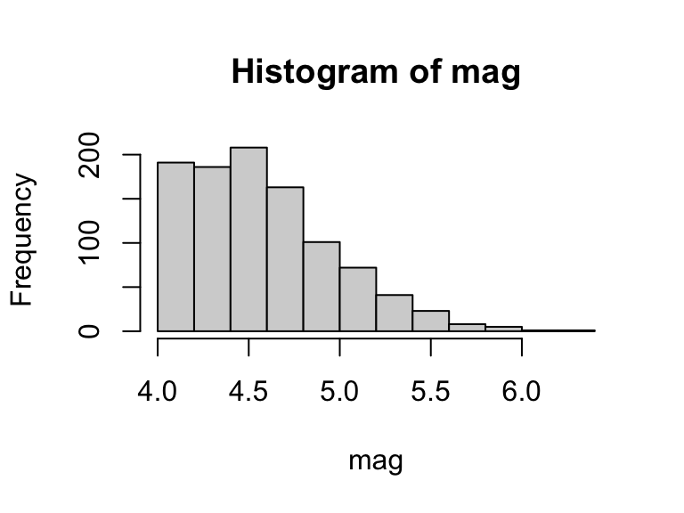

```r
hist(mag) #to see the distribution
```

```r
# In development, source the 2.0-1 R files to override the installed 1.0-5 functions.
# The library() call above is still needed to make package datasets available.
# When the 2.0-1 package is properly installed, the if-block below is a no-op.
local({
  r_dir <- file.path("..", "R")
  if (dir.exists(r_dir))
    invisible(lapply(list.files(r_dir, pattern = "\\.R$", full.names = TRUE), source))
})
res <- strata.data(mag, h = 2, n=300) # a 2-strata solution
summary(res)
```

```
#> <div style='margin-bottom:0.5rem'><span style='color:#0b7285;font-weight:700'>Stratification summary</span></div>
#> <div><span style='color:#0b7285;font-weight:600'>Strata (h):</span> 2 &nbsp; <span style='color:#0b7285;font-weight:600'>n:</span> 300 &nbsp; <span style='color:#0b7285;font-weight:600'>N:</span> 1000</div>
#> <div><span style='color:#0b7285;font-weight:600'>Data range:</span> [4.0000, 6.4000]  (d = 2.4000)</div>
#> <div><span style='color:#0b7285;font-weight:600'>Best-fit distribution:</span> lnorm</div>
#>
#>
#>
#> Table: Parameter estimate(s)
#>
#> |Parameter | Estimate|
#> |:---------|--------:|
#> |meanlog   | 1.526810|
#> |sdlog     | 0.085036|
```

Per-stratum results and totals

| Strata | OSB | Wh | Vh | WhSh | nh | Nh | fh |
| --- | --- | --- | --- | --- | --- | --- | --- |
| 1 | 4.68 | 0.58 | 0.03 | 0.109 | 140 | 585 | 0.24 |
| 2 | 6.4 | 0.42 | 0.09 | 0.124 | 160 | 415 | 0.38 |
| Total |  | 1.00 | 0.12 | 0.233 | 300 | 1000 | 0.30 |

All calculations have been rounded off to 2 decimal places, hence, the individual stratum solutions provided in the tables may not always add up to the totals.

## 6.2 The Function **strata.distr()**

This function is also used to compute the OSB, OSS, and other important quantities from univariate survey populations by employing the methodology proposed by Khan et al given earlier. Its algorithm is quite similar to that of the **strata.data()**, however, its functionality is applied to the case where the dataset of the population is not available and the distributonal assumptions of the study variable are strictly required. Another caveat for such distribution-based stratification is that the **distr.alloc()** function uses the probability density functions of the assumed distributions and integration rules presented by equations (4)-(6) to calculate the stratum sample sizes. It must be noted that this function works on ideal distributions that assumes the parameters chosen by the user. The usage and arguments are as follows:

```
    strata.distr(h, initval = NULL, dist = NULL,
                 distr = c("pareto", "triangle", "rtriangle", "weibull", "gamma",
                 "exp", "unif","norm", "lnorm", "cauchy"), params = c(shape=0,
                 scale=0, rate=0, gamma=0, location=0, mean=0, sd=0, meanlog=0,
                 sdlog=0, min=0, max=0, mode=0), n, N, cost=FALSE, ch=NULL,
                 method=c("dp","cobyla","global"),
                 n_starts=20L, max_iter=2000L, tol=1e-9, verbose=FALSE)
```

```
    h        - A numeric: number of strata to be sampled
    initval  - A numeric: initial value of the assumed distribution
    dist     - A numeric: distance or range of the assumed distribution
    distr    - A character: the assumed distribution of the hypothetical population
    params   - A list: parameters of the assumed distribution
    n        - A numeric: fixed total sample size
    N        - A numeric: fixed population size
    cost     - A logical: stratum cost. Default cost=FALSE.
    ch       - A numeric: denotes a vector of stratum costs. Default ch=NULL.
    method   - A character: optimisation method. One of "dp" (default), "cobyla" or "global".
    n_starts - An integer: number of random restarts for COBYLA. Default 20.
    max_iter - An integer: maximum function evaluations per COBYLA run. Default 2000.
    tol      - A numeric: convergence tolerance for COBYLA. Default 1e-9.
    verbose  - A logical: if TRUE, prints per-start diagnostics. Default FALSE.
```

The algorithm for **strata.distr()** is quite similar to the **strata.data()** for the contruction of OSB. It is only at the sample allocation (OSS) stage that the two are different. **strata.distr()** is the main function and once the OSB have been computed, this function uses the **distr.alloc()** function which uses the numerical integration rules for different distibutions (i.e., the equations (4)-(6)) to compute the OSS.

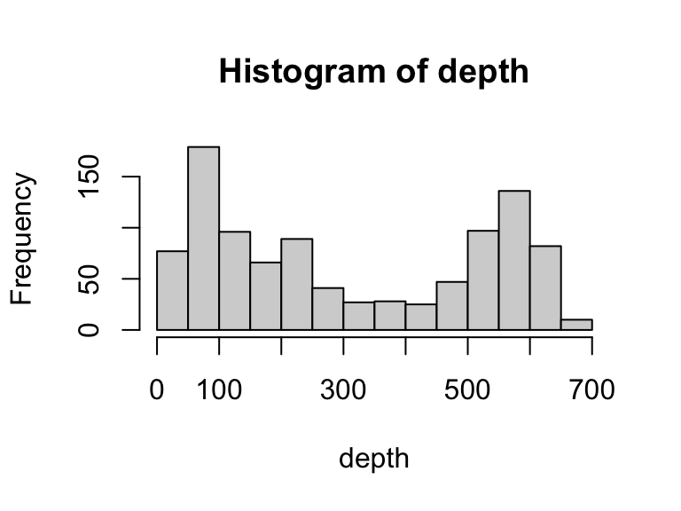

```r
data(quakes)
depth <- quakes$depth
hist(depth) #see distribution
```

```r
min(depth); max(depth); d=max(depth)-min(depth);d #min, max and range of data
```

```
#> [1] 40
#> [1] 680
#> [1] 640
```

```r
# the 2-strata solution is
res <- strata.distr(h=2, initval=40, dist=640, distr = "triangle",
             params = c(min=39.99998, max=680, mode=39.99999), n=300, N=1000)
```

```
#> The program is running, it'll take some time!
```

```r
summary(res)
```

```
#> <div style='margin-bottom:0.5rem'><span style='color:#0b7285;font-weight:700'>Stratification summary</span></div>
#> <div><span style='color:#0b7285;font-weight:600'>Strata (h):</span> 2 &nbsp; <span style='color:#0b7285;font-weight:600'>n:</span> 300 &nbsp; <span style='color:#0b7285;font-weight:600'>N:</span> 1000</div>
#> <div><span style='color:#0b7285;font-weight:600'>Data range:</span> [40.0000, 680.0000]  (d = 640.0000)</div>
#> <div><span style='color:#0b7285;font-weight:600'>Best-fit distribution:</span> triangle</div>
#>
#>
#>
#> Table: Parameter estimate(s)
#>
#> |Parameter |  Estimate|
#> |:---------|---------:|
#> |min       |  39.99998|
#> |max       | 680.00000|
#> |mode      |  39.99999|
```

Per-stratum results and totals

| Strata | OSB | Wh | Vh | WhSh | nh | Nh | fh |
| --- | --- | --- | --- | --- | --- | --- | --- |
| 1 | 266.72 | 0.58 | 4217.34 | 37.861 | 145 | 583 | 0.25 |
| 2 | 680 | 0.42 | 9488.91 | 40.620 | 155 | 417 | 0.37 |
| Total |  | 1.00 | 13706.25 | 78.481 | 300 | 1000 | 0.30 |

# 7 Alternative Optimisation Methods: COBYLA and GLOBAL

## 7.1 Motivation

The Dynamic Programming solver described in Section 4 is the foundation of the original **stratifyR** package and guarantees finding the globally optimum stratum boundaries on a discrete grid of 1,000 candidate positions. While this is accurate and reliable, the exhaustive nature of the grid search means computation time grows with the number of strata $h$ and the resolution of the grid. For applications involving a large number of strata, or when fast approximate results are needed, for instance during exploratory analysis, simulation studies, or when stratifying a large number of variables simultaneously, it is advantageous to employ a faster optimisation method.

**stratifyR** 2.0-1 introduces two alternative optimisation methods, accessible through the `method` argument in both `strata.data()` and `strata.distr()`:

- `method = "cobyla"`: a multi-start gradient-free local optimiser based on COBYLA
- `method = "global"`: a two-phase global optimiser combining DIRECT-L with COBYLA refinement

The original DP solver remains available as `method = "dp"` and is the **default** for both functions, ensuring full backward compatibility with version 1.0-5. The two new methods are intended as complements to DP, trading some accuracy for speed, and are most effective when applied to distribution-based stratification (`strata.distr`) where the objective function is smooth and continuous.

## 7.2 The COBYLA Method (`method = "cobyla"`)

COBYLA (Constrained Optimisation By Linear Approximations) is a gradient-free, derivative-free nonlinear optimisation algorithm developed by Powell (1994). It minimises a nonlinear objective function subject to nonlinear inequality constraints by constructing successive linear approximations to both the objective and constraint functions. Unlike gradient-based methods, COBYLA does not require the objective function to be differentiable, making it in principle applicable to the stratification objective $\sum_{h=1}^{L} W_h S_h$.

In **stratifyR**, COBYLA is applied with multiple random starting points (controlled by the `n_starts` argument, default 20) to reduce sensitivity to local minima. At each start, it searches for the $(h-1)$ interior boundary positions that minimise the objective, subject to constraints that keep boundaries ordered and prevent any stratum from collapsing to near-zero width. The best solution found across all starts is returned. If the solution is detected as degenerate (a stratum has collapsed), the solver automatically falls back to the DP method.

For `strata.distr`, COBYLA optimises the same analytical objective function evaluated by the DP solver, but treats the boundary positions as continuous variables rather than a discrete grid. Because this function is smooth and differentiable almost everywhere, COBYLA can navigate it effectively and typically converges to a solution close to the DP optimum in a fraction of the computation time.

For `strata.data`, COBYLA optimises an empirical objective computed directly from the raw data (stratum weights $W_h$ and standard deviations $S_h$ calculated by binning actual observations at each candidate boundary). This objective is piecewise constant, it only changes value when a boundary crosses an actual data point, which means continuous optimisers cannot reliably find the global minimum. For this reason, `method = "cobyla"` and `method = "global"` are most suitable for `strata.distr`, and `method = "dp"` is always recommended for `strata.data`.

**Advantages of COBYLA:**

- Substantially faster than DP, particularly for larger $h$, making it well-suited to exploratory work and simulation studies
- No derivative information required; the algorithm is self-contained
- Multiple random restarts reduce (but do not eliminate) sensitivity to local minima
- Well-suited to distribution-based stratification where the analytical objective is smooth and continuous

**Disadvantages of COBYLA:**

- Not guaranteed to find the global optimum; the result may vary slightly between runs due to random starting points
- For data-based stratification, cannot reliably match the DP result because the empirical Wh·Sh objective is piecewise constant
- Degeneracy risk (collapsed strata) is handled automatically by a fallback to DP, but this removes the speed advantage in such cases

## 7.3 The GLOBAL Method (`method = "global"`)

The `"global"` method employs a two-phase approach designed to improve upon single-phase COBYLA by systematically exploring the search space before local refinement.

**Phase 1 — DIRECT-L global search.** The DIRECT-L algorithm (Dividing RECTangles, locally-biased variant; Gablonsky and Kelley (2001)) partitions the feasible search space into hyper-rectangles and evaluates the objective at the centre of each. It then subdivides rectangles that are either (a) small and promising (local exploitation), or (b) large and unexplored (global coverage), ensuring that the entire feasible region is investigated over time. Unlike COBYLA, DIRECT-L does not depend on random starting points and provides deterministic, reproducible exploration of the search space. The algorithm continues until the evaluation budget (governed by `max_iter`) is exhausted.

**Phase 2 — COBYLA local refinement.** The best boundary position found by DIRECT-L in Phase 1 is used as the starting point for a COBYLA local refinement step, which polishes the solution to the required tolerance. This combination leverages the global coverage of DIRECT-L and the precise local convergence of COBYLA.

For `strata.distr`, this two-phase approach is most effective: DIRECT-L identifies the basin of attraction containing the global minimum of the smooth analytical objective, and COBYLA precisely locates the minimum within that basin. The result typically agrees very closely with the DP optimum while running considerably faster for larger $h$.

As with COBYLA, if the resulting solution is detected as degenerate, an automatic fallback to DP is applied.

**Advantages of the GLOBAL method:**

- Deterministic global search (Phase 1) avoids sensitivity to random starting points
- More thorough coverage of the feasible space than multi-start COBYLA
- Closest among the three methods to matching DP results for `strata.distr`
- Well-suited to distribution-based stratification problems where the highest accuracy and speed are both desired

**Disadvantages of the GLOBAL method:**

- Slower than COBYLA (though still faster than DP for large $h$) due to DIRECT-L’s evaluation budget
- For data-based stratification, does not reliably match DP, for the same reasons as COBYLA
- Degeneracy fallback to DP is applied automatically if the global search returns collapsed strata